# Разработка модели регрессии для молочной фермы

### Диаграммы рассеяния

Далее изучим связи числовых признаков с категориальными признаками, построив диаграммы рассеяния.

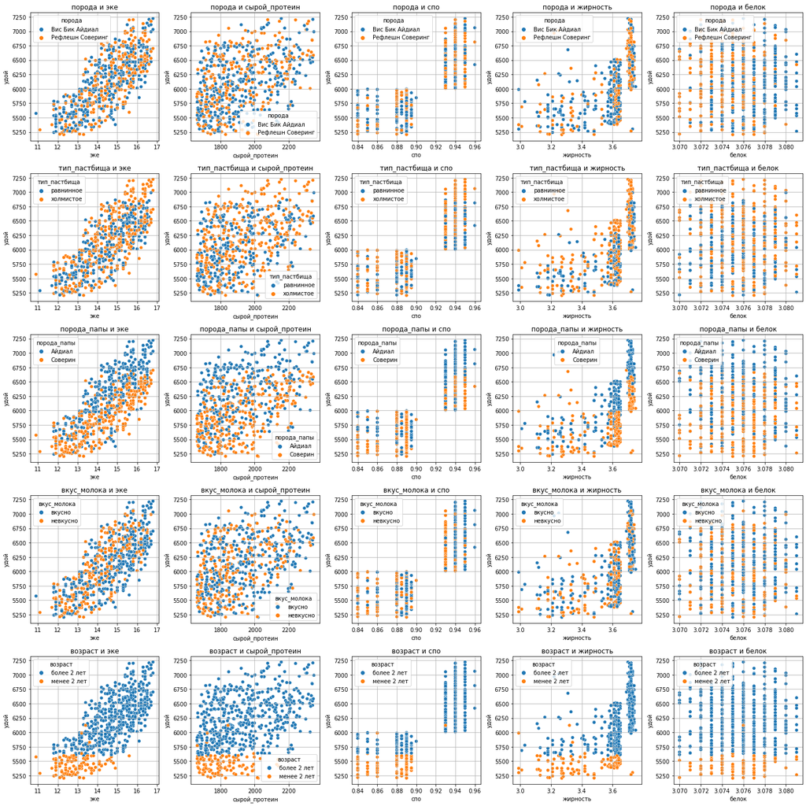

```python
fig, axs = plt.subplots(5, 5, figsize=(20, 20))
axs = axs.flatten()

for i, hue in enumerate(cat_col(main_data)):

    for j, x in enumerate(int_col(main_data)[2:]):

        # Вычисляем индекс для текущего графика
        plot_index = i * 5 + j

        sns.scatterplot(data=main_data, ax=axs[plot_index], x=x, y='удой', hue=hue)
        axs[plot_index].grid(True)
        axs[plot_index].set_title(f'{hue} и {x}')

plt.tight_layout()
plt.show()
```

**Порода коров:**

Коровы породы "Вис Бик Айдиал" в более высоких показателях ЭКЕ встречаются чуть реже, чем "Рефлешн Соверинг". Также небольшая связь заметна в показателях удоя и жирности молока коровы - "Вис Бик Айдиал" чуть меньше имеют высокие показатели, чем "Рефлешн Соверинг", что как раз может быть связано с тем, что они имеют чуть более низкие характеристики корма.

В показателях содержания белка в молоке можно заметить обратную картину - коровы породы "Вис Бик Айдиал" чаще имеют более высокие значения, чем "Рефлешн Соверинг".

**Тип пастбища:**

Высокие показатели удоя заметно чаще встречаются у коров, пасущихся на холмах.

Также небольшая связь заметна в показателях ЭКЕ и СПО корма коровы - коровы с холмистых пастбищ чуть чаще имеют высокие показатели, чем коровы с равнин.

**Порода папы быка коров:**

По параметрам удоя очень сильно заметна разница - более высокие показатели гораздо чаще имеют коровы с породой папы быка "Айдиал". Также видна связь с показателем СПО и ЭКЕ корма коровы - здесь также в высоких значениях предобладают "Айдиал".

**Вкус молока:**

Коровы с вкусным молоком чуть чаще имеют более высокие значения по ЭКЕ, СПО и содержанию сырого протеина в корме.

Также коровы с вкусным молоком отличаются чуть более высокими показателями удоя, содержания белка и жира в молоке.

**Возраст коров:**

По большинству параметров можно увидеть сильную связь с возрастом коровы.

У коров старше 2 лет более питательный корм - среди показателей СПО, ЭКЕ и содержания сырого протеина в корме эта категория коров гораздо чаще имеет высокие показатели.

Также очевидна разница в удое и жирности молока коров - у коров старше 2 лет эти показатели гораздо выше.

**Количественные признаки:**

На графике можно заметить, что удой и ЭКЕ имеют зависимость между линейной и квадратичной.

Связь между удоем и количеством сырого протеина в корме коровы выглядит как линейная, но она очень слабая.

СПО и удой связаны нелинейно. На их диаграмме рассеяния наблюдения разделены на две четкие группы.

Между жирностью молока и удоем можно заметить нелинейную связь, но она случайна, т.к. на эти характеристики влияют схожие параметры.

Содержание белка в молоке и удой не имеют связи, распределение наблюдений похоже на случайное.

### Вывод

По целевым признакам мы выяснили следующее:

**Удой:**

- Возраст коров имеет прямую связь с удоем - взрослые коровы имеют больший удой.
- Самое сильное влияние на удой имеет сахаро-протеиновое соотношение в корме коровы (СПО). Связь больше похожа на категориальную, чем на линейную, есть четкое разделение на группы - коровы с соотношением сахара к протеину более 0.92 имеют удой от 6000 кг и более, менее 0.92 - до 6000 кг. Стоит добавить дополнительный признак, который отобразит СПО как категориальный признак.
- На втором месте по влиянию на удой находится энергетическая кормовая единица (ЭКЕ). Зависимость похожа на квадратичную, поэтому этот признак также стоит трансформировать, чтобы исключить нелинейность, вjзведя значения в квадрат.
- Порода папы быка коров тоже показала заметную связь с удоем - порода папы быка Айдиал демонстрирует более высокие показатели.
- Среднюю связь со слабой линейной зависимостью удой имеет с содержанием сырого протеина в корме.
- Жирность и удой имеют высокий коэффициент корреляции, но между собой они не связаны, так как оба эти параметра относятся к характеристикам молока. Связь объясняется тем, что оба эти параметра имеют сильную связь с СПО и ЭКЕ.

**Вкус молока:**

По вкусу молока нет таких признаков, которые бы имели сильную прямую связь с ним, но есть признаки с заметной или слабой корреляцией:

- Самое заметное влияние на вкус молока имеет сахаро-протеиновое соотношение в корме коровы (СПО).
- Затем далее по влиянию идет энергетическая кормовая единица (ЭКЕ) и тип пастбища.

Вернуться к содержанию

## Обучение модели линейной регрессии

Обучим модель простой линейной регрессии.

Добавим аргумент `random_state`, чтобы при каждом перезапуске блокнота датасет делился на выборки одинаково.

```python
RANDOM_STATE = 42
```

Целевой признак - `'удой'`.

```python
y = main_data['удой']
```

Разбиваем целевой признак на тренировочную и тестовую выборки.

```python
y_train, y_test = train_test_split(y, random_state=RANDOM_STATE)
```

### Первая модель

Из входных признаков исключим:

- целевые `'удой'` и `'вкус_молока'`,
- характеристики молока `'белок'` и `'жирность'` (т.к. `'удой'` является одной из характеристик молока, другие характеристики не могут влиять на него),
- `'ид'`, который ни с чем не связан.

```python
X_1 = main_data.drop(['удой', 'вкус_молока', 'белок', 'жирность', 'ид'], axis=1)

# Создаем переменные, которые разделяют признаки на категориальные и количественные
cat_col_names_1 = cat_col(X_1)
num_col_names_1 = int_col(X_1)

# Подготовим данные, разбив входные признаки на тренировочную и тестовую выборки
X_train_1, X_test_1 = train_test_split(X_1, random_state=RANDOM_STATE)
```

Обучаем первую модель.

```python
# Кодируем категориальные признаки с помощью OneHotEncoder
encoder_1 = OneHotEncoder(drop='first', sparse=False)

X_train_ohe_1 = encoder_1.fit_transform(X_train_1[cat_col_names_1])
X_test_ohe_1 = encoder_1.transform(X_test_1[cat_col_names_1])

encoder_col_names_1 = encoder_1.get_feature_names()

X_train_ohe_1 = pd.DataFrame(X_train_ohe_1, columns=encoder_col_names_1)
X_test_ohe_1 = pd.DataFrame(X_test_ohe_1, columns=encoder_col_names_1)


# Масштабируем количественные признаки с помощью StandardScaler
scaler_1 = StandardScaler()

X_train_scaled_1 = scaler_1.fit_transform(X_train_1[num_col_names_1])
X_test_scaled_1 = scaler_1.transform(X_test_1[num_col_names_1])


# Объединяем все преобразованные данные в тренировочный и тестовый датафреймы
X_train_scaled_1 = pd.DataFrame(X_train_scaled_1, columns=num_col_names_1)
X_test_scaled_1 = pd.DataFrame(X_test_scaled_1, columns=num_col_names_1)

X_train_1 = pd.concat([X_train_ohe_1, X_train_scaled_1], axis=1)
X_test_1 = pd.concat([X_test_ohe_1, X_test_scaled_1], axis=1)


# Обучаем модель линейной регрессии на подготовленных данных и получаем прогноз удоя коров
model_lr_1 = LinearRegression()

model_lr_1.fit(X_train_1, y_train)

y_pred_1 = model_lr_1.predict(X_test_1)
```

Оценим качество модели на тестовой выборке, рассчитав R² при помощи функции `R2`.

```python
print('R2 =', R2(y_pred_1))
```

```
R2 = 0.7832029531509055
```

Проанализируем остатки с помощью графиков, используя функцию `residuals_plot`.

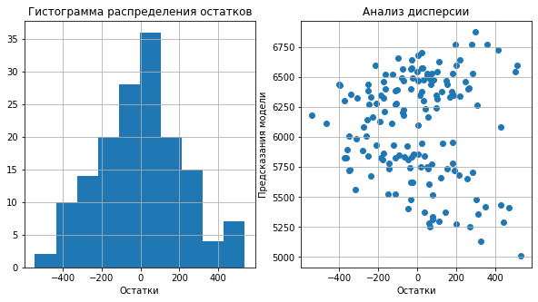

```python
residuals_plot(y_pred_1)
```

R² = 0.783. Модель в 78.3% случаев предсказывает верно.

Распределение остатков несимметричное, не похоже на нормальное, на графике можно увидеть две вершины - бимодальное распределение. Эта модель работает недостаточно точно, её результаты можно улучшить.

Также можно увидеть, что распределение остатков смещено вправо, что говорит о недооценивании реальных значений целевого признака. Прогнозы модели меньше фактических показателей.

Дисперсия образует слабую дугу. Модель достаточно симметрично ошибается как на самых низких, так и на самых высоких предсказаниях. При чем во всех случаях завышает их. Модель может работать неустойчиво.

Необходимо провести дополнительные исследования. Попробуем повысить качество модели и трансформировать имеющиеся данные, чтобы изменить взаимосвязь входных признаков с целевым.

### Вторая модель

При изучении диаграмм рассеяния можно заметить, что `'спо'` и `'эке'` связаны с целевым нелинейно. Исключим нелинейность:

- На диаграмме рассеяния `'спо'` наблюдения сгруппированы в два кластера. Преобразуем `'спо'` в категориальный бинарный признак.
- Нелинейность между `'эке'` и `'удой'` исключим, возведя признак `'эке'` в квадрат.

```python
main_data['спо_категория'] = 0
main_data.loc[main_data['спо'] > 0.92, 'спо_категория'] = 1
```

```python
main_data['квадрат_эке'] = main_data['эке'] ** 2
```

```python
main_data.tail()
```

|  | ид | удой | эке | сырой_протеин | спо | порода | тип_пастбища | порода_папы | жирность | белок | вкус_молока | возраст | спо_категория | квадрат_эке |
| --- | --- | --- | --- | --- | --- | --- | --- | --- | --- | --- | --- | --- | --- | --- |
| 624 | 625 | 6812 | 15.4 | 1964 | 0.94 | Рефлешн Соверинг | равнинное | Айдиал | 3.74 | 3.075 | невкусно | более 2 лет | 1 | 237.16 |
| 625 | 626 | 5513 | 12.9 | 1700 | 0.88 | Рефлешн Соверинг | равнинное | Соверин | 3.64 | 3.073 | вкусно | менее 2 лет | 0 | 166.41 |
| 626 | 627 | 5970 | 14.4 | 1837 | 0.88 | Рефлешн Соверинг | холмистое | Соверин | 3.64 | 3.075 | невкусно | более 2 лет | 0 | 207.36 |
| 627 | 628 | 5746 | 13.8 | 1994 | 0.89 | Рефлешн Соверинг | равнинное | Соверин | 3.64 | 3.077 | вкусно | более 2 лет | 0 | 190.44 |
| 628 | 629 | 6503 | 16.2 | 2283 | 0.94 | Вис Бик Айдиал | холмистое | Соверин | 3.71 | 3.076 | вкусно | более 2 лет | 1 | 262.44 |

Новые признаки добавлены. Из входных признаков исключим старые признаки `'спо'` и `'эке'`.

```python
X_2 = main_data.drop(['удой', 'вкус_молока', 'белок', 'жирность', 'ид', 'спо', 'эке'], axis=1)

# Создаем переменные, которые разделяют признаки на категориальные и количественные
cat_col_names_2 = cat_col(X_2)
num_col_names_2 = int_col(X_2)

# Подготовим данные, разбив входные признаки на тренировочную и тестовую выборки
X_train_2, X_test_2 = train_test_split(X_2, random_state=RANDOM_STATE)
```

Обучаем вторую модель.

```python
# Кодируем категориальные признаки с помощью OneHotEncoder
encoder_2 = OneHotEncoder(drop='first', sparse=False)

X_train_ohe_2 = encoder_2.fit_transform(X_train_2[cat_col_names_2])
X_test_ohe_2 = encoder_2.transform(X_test_2[cat_col_names_2])

encoder_col_names_2 = encoder_2.get_feature_names()

X_train_ohe_2 = pd.DataFrame(X_train_ohe_2, columns=encoder_col_names_2)
X_test_ohe_2 = pd.DataFrame(X_test_ohe_2, columns=encoder_col_names_2)


# Масштабируем количественные признаки с помощью StandardScaler
scaler_2 = StandardScaler()

X_train_scaled_2 = scaler_2.fit_transform(X_train_2[num_col_names_2])
X_test_scaled_2 = scaler_2.transform(X_test_2[num_col_names_2])


# Объединяем все преобразованные данные в тренировочный и тестовый датафреймы
X_train_scaled_2 = pd.DataFrame(X_train_scaled_2, columns=num_col_names_2)
X_test_scaled_2 = pd.DataFrame(X_test_scaled_2, columns=num_col_names_2)

X_train_2 = pd.concat([X_train_ohe_2, X_train_scaled_2], axis=1)
X_test_2 = pd.concat([X_test_ohe_2, X_test_scaled_2], axis=1)


# Обучаем модель линейной регрессии на подготовленных данных и получаем прогноз удоя коров
model_lr_2 = LinearRegression()

model_lr_2.fit(X_train_2, y_train)

y_pred_2 = model_lr_2.predict(X_test_2)
```

Оценим качество модели на тестовой выборке, рассчитав R².

```python
print('R2 =', R2(y_pred_2))
```

```
R2 = 0.8347436421181885
```

Проанализируем остатки с помощью графиков.

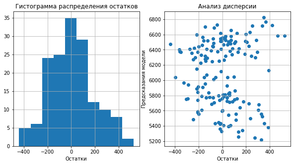

```python
residuals_plot(y_pred_2)
```

R² = 0.834. Качество модели значительно повысилось - на 5.1% (83.4%).

На гистограмме распределение уже больше похоже на нормальное, но оно не симметричное.

В анализе остатков по дисперсии дуга все еще присутствует.

Необходимо провести дополнительные исследования. Попробуем добавить в модель дополнительный признак.

### Третья модель

Добавим в датасет `main_data` признак `'имя_папы'` из датафрейма `dad_data`.

Проверим исходный размер датасета `main_data` и количество пропущенных значений.

```python
main_data.shape
```

```
(623, 14)
```

```python
main_data.isna().sum().sum()
```

```
0
```

Объединяем таблицы.

```python
main_data = main_data\
.merge(
    dad_data,
    on='ид',
    how='left')
```

Проверяем результат.

```python
main_data.shape
```

```
(623, 15)
```

```python
main_data.isna().sum().sum()
```

```
0
```

```python
main_data.head()
```

|  | ид | удой | эке | сырой_протеин | спо | порода | тип_пастбища | порода_папы | жирность | белок | вкус_молока | возраст | спо_категория | квадрат_эке | имя_папы |
| --- | --- | --- | --- | --- | --- | --- | --- | --- | --- | --- | --- | --- | --- | --- | --- |
| 0 | 1 | 5863 | 14.2 | 1743 | 0.890 | Вис Бик Айдиал | равнинное | Айдиал | 3.58 | 3.076 | вкусно | более 2 лет | 0 | 201.64 | Буйный |
| 1 | 2 | 5529 | 12.8 | 2138 | 0.890 | Вис Бик Айдиал | равнинное | Соверин | 3.54 | 3.079 | вкусно | менее 2 лет | 0 | 163.84 | Соловчик |
| 2 | 3 | 5810 | 14.0 | 1854 | 0.885 | Рефлешн Соверинг | холмистое | Соверин | 3.59 | 3.074 | невкусно | более 2 лет | 0 | 196.00 | Барин |
| 3 | 4 | 5895 | 12.4 | 2012 | 0.885 | Рефлешн Соверинг | холмистое | Айдиал | 3.40 | 3.075 | невкусно | более 2 лет | 0 | 153.76 | Буйный |
| 4 | 5 | 5302 | 12.8 | 1675 | 0.885 | Вис Бик Айдиал | равнинное | Соверин | 3.73 | 3.073 | вкусно | менее 2 лет | 0 | 163.84 | Барин |

Изучим корреляцию нового признака с другими признаками.

```python
display(HTML('<h3>Корреляция признака "имя_папы" с другими признаками</h3>'))
main_data[main_data.columns[1:]]\
    .phik_matrix(interval_cols=int_col(main_data))\
    .drop(main_data.columns[1:-1], axis=1)\
    .style.background_gradient('cividis')
```

Корреляция признака "имя_папы" с другими признаками

|  | имя_папы |
| --- | --- |
| удой | 0.433260 |
| эке | 0.081018 |
| сырой_протеин | 0.099075 |
| спо | 0.407679 |
| порода | 0.378483 |
| тип_пастбища | 0.226376 |
| порода_папы | 0.983494 |
| жирность | 0.097142 |
| белок | 0.087294 |
| вкус_молока | 0.000000 |
| возраст | 0.389225 |
| спо_категория | 0.459845 |
| квадрат_эке | 0.096304 |
| имя_папы | 1.000000 |

Заметна практически прямая корреляция между именем и породы папы коров. Эти два признака очень похожи, поэтому необходимо оставить только один из них.

Из входных признаков исключим `'порода_папы'`.

```python
X_3 = main_data.drop(['удой', 'вкус_молока', 'белок', 'жирность', 'ид', 'спо', 'эке', 'порода_папы'], axis=1)

# Создаем переменные, которые разделяют признаки на категориальные и количественные
cat_col_names_3 = cat_col(X_3)
num_col_names_3 = int_col(X_3)

# Подготовим данные, разбив входные признаки на тренировочную и тестовую выборки
X_train_3, X_test_3 = train_test_split(X_3, random_state=RANDOM_STATE)
```

Обучаем третью модель.

```python
# Кодируем категориальные признаки с помощью OneHotEncoder
encoder_3 = OneHotEncoder(drop='first', sparse=False)

X_train_ohe_3 = encoder_3.fit_transform(X_train_3[cat_col_names_3])
X_test_ohe_3 = encoder_3.transform(X_test_3[cat_col_names_3])

encoder_col_names_3 = encoder_3.get_feature_names()

X_train_ohe_3 = pd.DataFrame(X_train_ohe_3, columns=encoder_col_names_3)
X_test_ohe_3 = pd.DataFrame(X_test_ohe_3, columns=encoder_col_names_3)


# Масштабируем количественные признаки с помощью StandardScaler
scaler_3 = StandardScaler()

X_train_scaled_3 = scaler_3.fit_transform(X_train_3[num_col_names_3])
X_test_scaled_3 = scaler_3.transform(X_test_3[num_col_names_3])


# Объединяем все преобразованные данные в тренировочный и тестовый датафреймы
X_train_scaled_3 = pd.DataFrame(X_train_scaled_3, columns=num_col_names_3)
X_test_scaled_3 = pd.DataFrame(X_test_scaled_3, columns=num_col_names_3)

X_train_3 = pd.concat([X_train_ohe_3, X_train_scaled_3], axis=1)
X_test_3 = pd.concat([X_test_ohe_3, X_test_scaled_3], axis=1)


# Обучаем модель линейной регрессии на подготовленных данных и получаем прогноз удоя коров
model_lr_3 = LinearRegression()

model_lr_3.fit(X_train_3, y_train)

y_pred_3 = model_lr_3.predict(X_test_3)
```

Оценим качество модели на тестовой выборке, рассчитав R².

```python
print('R2 =', R2(y_pred_3))
```

```
R2 = 0.8431654640899504
```

Проанализируем остатки с помощью графиков.

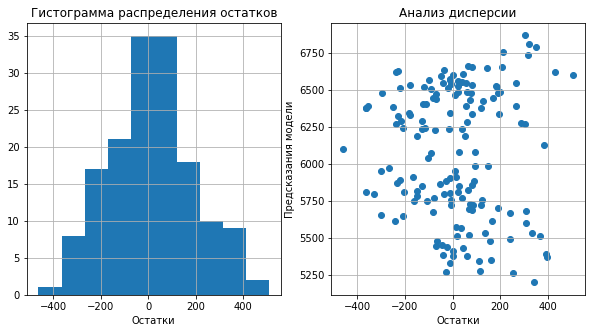

```python
residuals_plot(y_pred_3)
```

R² = 0.843. Качество модели немного повысилось - на 0.9% (84.3%).

На гистограмме распределение остатков нормальное.

В анализе остатков по дисперсии не удалось избавиться от дуги, но в целом все стало симметричнее, а распределение выглядит практически как случайное.

### Сравнение качества трёх моделей

Сравним качество трёх моделей линейной регрессии, сопоставим полученные остатки и значения R². Также оцениим качество каждой модели по трём метрикам: MSE, MAE, RMSE.

Для удобства подсчета сохраним полученные предсказания от всех моделей в одну переменную.

```python
predictions = [y_pred_1, y_pred_2, y_pred_3]
```

**Остатки моделей**

**Графики по остаткам 1 модели**

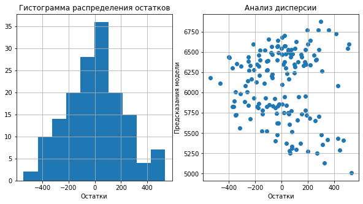

**Графики по остаткам 2 модели**

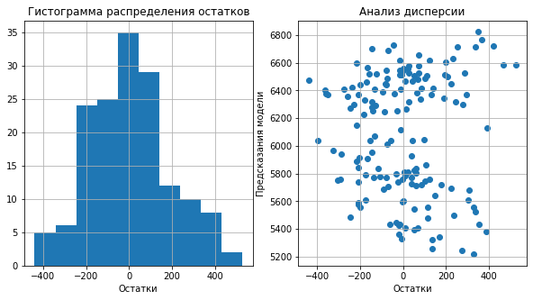

**Графики по остаткам 3 модели**

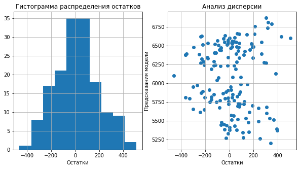

```python
for i, prediction in enumerate(predictions, start=1):
    display(HTML(f'<br><b>Графики по остаткам {i} модели</b>'))
    residuals_plot(prediction)
```

Самое хорошее нормальное распределение остатков мы можем увидеть у 3 модели. Ее дисперсия стала чуть более компактной и дуга наименее выражена.

**R²**

```python
for i, prediction in enumerate(predictions, start=1):
    print(f'R2 {i} модели = {R2(prediction)}')
```

```
R2 1 модели = 0.7832029531509055
R2 2 модели = 0.8347436421181885
R2 3 модели = 0.8431654640899504
```

**MAE**

```python
for i, prediction in enumerate(predictions, start=1):
    print(f'MAE {i} модели = {mean_absolute_error(y_test, prediction)}')
```

```
MAE 1 модели = 173.80122314737423
MAE 2 модели = 149.71979977040334
MAE 3 модели = 144.19665221091074
```

Средняя абсолютная ошибка MAE у 3 модели меньше на 29.6 и 5.5, чем у 1 и 2 моделей, что ее показатель в 144.2 делает ее лучшей среди трёх моделей.

**MSE**

```python
for i, prediction in enumerate(predictions, start=1):
    print(f'MSE {i} модели = {mean_squared_error(y_test, prediction)}')
```

```
MSE 1 модели = 47499.999455259895
MSE 2 модели = 36207.49001635703
MSE 3 модели = 34362.27789338271
```

Средняя квадратическая ошибка MSE у 3 модели меньше на 13137.7 и 1845.2, чем у 1 и 2 моделей, что ее показатель в 34362.3 делает ее лучшей среди трёх моделей.

**RMSE**

```python
for i, prediction in enumerate(predictions, start=1):
    print(f'RMSE {i} модели = {mean_squared_error(y_test, prediction, squared=False)}')
```

```
RMSE 1 модели = 217.94494592731417
RMSE 2 модели = 190.28265821234743
RMSE 3 модели = 185.37065003226024
```

Корень среднего квадрата ошибок RMSE у 3 модели меньше на 32.5 и 4.9, чем у 1 и 2 моделей, что ее показатель в 185.4 делает ее лучшей среди трёх моделей.

**Лучшая модель**

По всем показателям лучше всех себя показала модель № 3. Рассчитаем доверительный интервал её прогноза.

```python
print('95% доверительный интервал =', st.norm.interval(0.95, loc=np.mean(y_pred_3), scale=st.sem(y_pred_3)))
```

```
95% доверительный интервал = (6006.236664575742, 6143.867738633781)
```

С 95% вероятностью истинное значение удоя коров будет находиться в интервале от 6006.24 до 6143.87 кг.

Интервал довольно узкий, это говорит о том, что прогнозы третьей модели достаточно точны.

Для прогнозирования удоя коров мы будем использовать именно её.

### Прогнозирование удоя коров

Перед составлением прогноза добавим в датасет недостающие признаки `'сырой_протеин'`, `'эке'` и `'спо'`. Для этого возьмём из датасета `main_data` средние значения каждого из признаков и увеличим их на 5%, т.к. для новых коров планируется увеличить значения каждого из этих параметров на 5%.

Рассчитываем необходимые показатели.

```python
buy_data[['эке', 'спо', 'сырой_протеин']] = 0

for column in ['эке', 'спо', 'сырой_протеин']:

    young_cows = main_data['возраст'] == 'менее 2 лет'
    adult_cows = main_data['возраст'] == 'более 2 лет'

    for cows_age in [young_cows, adult_cows]:
        buy_data.loc[cows_age, column] = main_data.loc[cows_age, column].mean() * 1.05
```

Также добавим ранее созданные нами признаки `'квадрат_эке'` и `'спо_категория'`.

```python
buy_data['квадрат_эке'] = buy_data['эке'] ** 2
```

```python
buy_data['спо_категория'] = 0
buy_data.loc[buy_data['спо'] > 0.92, 'спо_категория'] = 1
```

Проверяем результат.

```python
buy_data.head()
```

|  | порода | тип_пастбища | порода_папы | имя_папы | жирность | белок | возраст | эке | спо | сырой_протеин | квадрат_эке | спо_категория |
| --- | --- | --- | --- | --- | --- | --- | --- | --- | --- | --- | --- | --- |
| 0 | Вис Бик Айдиал | холмистое | Айдиал | Геркулес | 3.58 | 3.076 | более 2 лет | 15.626615 | 0.967583 | 2045.120136 | 244.191090 | 1 |
| 1 | Вис Бик Айдиал | равнинное | Соверин | Буйный | 3.54 | 3.081 | менее 2 лет | 13.626881 | 0.918220 | 1900.239908 | 185.691879 | 0 |
| 2 | Рефлешн Соверинг | равнинное | Соверин | Барин | 3.59 | 3.074 | более 2 лет | 15.626615 | 0.967583 | 2045.120136 | 244.191090 | 1 |
| 3 | Рефлешн Соверинг | холмистое | Айдиал | Буйный | 3.40 | 3.061 | более 2 лет | 15.626615 | 0.967583 | 2045.120136 | 244.191090 | 1 |
| 4 | Рефлешн Соверинг | равнинное | Айдиал | Буйный | 3.64 | 3.074 | более 2 лет | 13.626881 | 0.918220 | 1900.239908 | 185.691879 | 0 |

Выполним подготовку данных и спрогнозируем удой коров, которых хочет купить фермер, используя модель № 3.

```python
# Подготовка данных
X_buy = buy_data.drop(['белок', 'жирность', 'порода_папы'], axis=1)

# Преобразование категориальных признаков
X_buy_ohe = encoder_3.transform(X_buy[cat_col_names_3])
X_buy_ohe = pd.DataFrame(X_buy_ohe, columns=encoder_col_names_3)

# Масштабирование числовых признаков
X_buy_scaled = scaler_3.transform(X_buy[num_col_names_3])
X_buy_scaled = pd.DataFrame(X_buy_scaled, columns=num_col_names_3)

# Объединение преобразованных признаков
X_buy = pd.concat([X_buy_ohe, X_buy_scaled], axis=1)

# Прогнозирование удоя коров
y_pred_buy = model_lr_3.predict(X_buy)
```

Получаем прогноз удоя коров.

```python
buy_data['удой'] = y_pred_buy

buy_data.sort_values(by='удой', ascending=False)
```

|  | порода | тип_пастбища | порода_папы | имя_папы | жирность | белок | возраст | эке | спо | сырой_протеин | квадрат_эке | спо_категория | удой |
| --- | --- | --- | --- | --- | --- | --- | --- | --- | --- | --- | --- | --- | --- |
| 0 | Вис Бик Айдиал | холмистое | Айдиал | Геркулес | 3.58 | 3.076 | более 2 лет | 15.626615 | 0.967583 | 2045.120136 | 244.191090 | 1 | 6660.253270 |
| 6 | Вис Бик Айдиал | холмистое | Айдиал | Геркулес | 3.58 | 3.076 | более 2 лет | 15.626615 | 0.967583 | 2045.120136 | 244.191090 | 1 | 6660.253270 |
| 12 | Вис Бик Айдиал | холмистое | Айдиал | Геркулес | 3.68 | 3.046 | более 2 лет | 15.626615 | 0.967583 | 2045.120136 | 244.191090 | 1 | 6660.253270 |
| 15 | Рефлешн Соверинг | холмистое | Айдиал | Буйный | 3.40 | 3.065 | более 2 лет | 15.626615 | 0.967583 | 2045.120136 | 244.191090 | 1 | 6650.321425 |
| 3 | Рефлешн Соверинг | холмистое | Айдиал | Буйный | 3.40 | 3.061 | более 2 лет | 15.626615 | 0.967583 | 2045.120136 | 244.191090 | 1 | 6650.321425 |
| 11 | Рефлешн Соверинг | равнинное | Соверин | Геркулес | 3.73 | 3.073 | более 2 лет | 15.626615 | 0.967583 | 2045.120136 | 244.191090 | 1 | 6644.277577 |
| 19 | Рефлешн Соверинг | равнинное | Айдиал | Буйный | 3.64 | 3.074 | более 2 лет | 15.626615 | 0.967583 | 2045.120136 | 244.191090 | 1 | 6597.944352 |
| 7 | Вис Бик Айдиал | равнинное | Соверин | Буйный | 3.57 | 3.079 | более 2 лет | 15.626615 | 0.967583 | 2045.120136 | 244.191090 | 1 | 6561.542972 |
| 18 | Вис Бик Айдиал | равнинное | Соверин | Буйный | 3.34 | 3.069 | более 2 лет | 15.626615 | 0.967583 | 2045.120136 | 244.191090 | 1 | 6561.542972 |
| 17 | Рефлешн Соверинг | равнинное | Соверин | Геркулес | 3.77 | 3.053 | менее 2 лет | 15.626615 | 0.967583 | 2045.120136 | 244.191090 | 1 | 6445.161206 |
| 16 | Вис Бик Айдиал | холмистое | Соверин | Соловчик | 3.73 | 3.079 | более 2 лет | 15.626615 | 0.967583 | 2045.120136 | 244.191090 | 1 | 6379.382631 |
| 8 | Рефлешн Соверинг | равнинное | Соверин | Барин | 3.59 | 3.074 | более 2 лет | 15.626615 | 0.967583 | 2045.120136 | 244.191090 | 1 | 6332.910287 |
| 14 | Рефлешн Соверинг | равнинное | Соверин | Барин | 3.59 | 3.074 | более 2 лет | 15.626615 | 0.967583 | 2045.120136 | 244.191090 | 1 | 6332.910287 |
| 2 | Рефлешн Соверинг | равнинное | Соверин | Барин | 3.59 | 3.074 | более 2 лет | 15.626615 | 0.967583 | 2045.120136 | 244.191090 | 1 | 6332.910287 |
| 13 | Вис Бик Айдиал | холмистое | Соверин | Барин | 3.42 | 3.075 | менее 2 лет | 15.626615 | 0.967583 | 2045.120136 | 244.191090 | 1 | 6149.769609 |
| 4 | Рефлешн Соверинг | равнинное | Айдиал | Буйный | 3.64 | 3.074 | более 2 лет | 13.626881 | 0.918220 | 1900.239908 | 185.691879 | 0 | 5951.232924 |
| 9 | Рефлешн Соверинг | холмистое | Айдиал | Буйный | 3.40 | 3.079 | менее 2 лет | 13.626881 | 0.918220 | 1900.239908 | 185.691879 | 0 | 5804.493625 |
| 5 | Рефлешн Соверинг | равнинное | Соверин | Геркулес | 3.63 | 3.053 | менее 2 лет | 13.626881 | 0.918220 | 1900.239908 | 185.691879 | 0 | 5798.449777 |
| 10 | Вис Бик Айдиал | холмистое | Соверин | Соловчик | 3.73 | 3.055 | более 2 лет | 13.626881 | 0.918220 | 1900.239908 | 185.691879 | 0 | 5732.671203 |
| 1 | Вис Бик Айдиал | равнинное | Соверин | Буйный | 3.54 | 3.081 | менее 2 лет | 13.626881 | 0.918220 | 1900.239908 | 185.691879 | 0 | 5715.715173 |

Построим график по спрогнозированным значениям.

```
Количество коров с удоем выше 6000 кг в год: 15
```

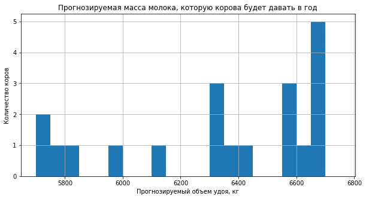

```python
print('Количество коров с удоем выше 6000 кг в год:', len(buy_data[buy_data['удой'] >= 6000]))
quantitative_plot(buy_data, 'удой', 50)
plt.title('Прогнозируемая масса молока, которую корова будет давать в год')
plt.xlabel('Прогнозируемый объем удоя, кг')
plt.show()
```

### Вывод

Для повышения качества модели мы сделали следующее:

- трансформировали признак `'спо'` в `'спо_категория'`, сделав его категориальным,
- трансформировали признак `'эке'` в `'квадрат_эке'`, возведя его в квадрат,
- добавили новый признак `'имя_папы'`.

Мы спрогнозировали удой коров, которых фермер хочет купить. По полученным данным можно сделать вывод, что фермеру для получения удоя свыше 6000 кг в год стоит покупать коров, которым больше двух лет. К требованиям фермера подходят 15 коров.

Вернуться к содержанию

## Обучение модели логистической регрессии

Обучим модель логистической регрессии.

Целевой признак - `'вкус_молока'`.

```python
y = main_data['вкус_молока']
```

Разбиваем целевой признак на тренировочную и тестовую выборки.

```python
y_train, y_test = train_test_split(y, random_state=RANDOM_STATE)
```

### Первая модель

Из входных признаков исключим:

- `'вкус_молока'` и `'удой'` (целевые),
- `'белок'` и `'жирность'` (другие характеристики молока),
- `'порода'`, `'порода_папы'` и `'имя_папы'` (не имеют никакой корреляции с целевым признаком),
- `'эке'` и `'спо'` (добавлены новые признаки взамен этих),
- `'ид'`.

```python
X_1 = main_data.drop(['вкус_молока', 'удой', 'ид', 'белок', 'жирность',
                    'порода', 'порода_папы', 'имя_папы', 'эке', 'спо'], axis=1)

# Создаем переменные, которые разделяют признаки на категориальные и количественные
cat_col_names_1 = cat_col(X_1)
num_col_names_1 = int_col(X_1)

# Разбиваем признаки на тренировочную и тестовую выборки
X_train_1, X_test_1 = train_test_split(X_1, random_state=RANDOM_STATE)
```

Обучаем первую модель.

```python
# Кодируем категориальные признаки с помощью OneHotEncoder
encoder_1 = OneHotEncoder(drop='first', sparse=False)

X_train_ohe_1 = encoder_1.fit_transform(X_train_1[cat_col_names_1])
X_test_ohe_1 = encoder_1.transform(X_test_1[cat_col_names_1])

encoder_col_names_1 = encoder_1.get_feature_names()

X_train_ohe_1 = pd.DataFrame(X_train_ohe_1, columns=encoder_col_names_1)
X_test_ohe_1 = pd.DataFrame(X_test_ohe_1, columns=encoder_col_names_1)


# Масштабируем количественные признаки с помощью StandardScaler
scaler_1 = StandardScaler()

X_train_scaled_1 = scaler_1.fit_transform(X_train_1[num_col_names_1])
X_test_scaled_1 = scaler_1.transform(X_test_1[num_col_names_1])


# Объединяем все преобразованные данные в тренировочный и тестовый датафреймы
X_train_scaled_1 = pd.DataFrame(X_train_scaled_1, columns=num_col_names_1)
X_test_scaled_1 = pd.DataFrame(X_test_scaled_1, columns=num_col_names_1)

X_train_1 = pd.concat([X_train_ohe_1, X_train_scaled_1], axis=1)
X_test_1 = pd.concat([X_test_ohe_1, X_test_scaled_1], axis=1)


# Обучаем модель линейной регрессии на подготовленных данных и получаем прогноз удоя коров

clf_1 = LogisticRegression(random_state=0)

clf_1.fit(X_train_1, y_train)

y_pred_1 = clf_1.predict(X_test_1)
```

Оценим качество модели на тестовой выборке, рассчитав метрики accuracy, precision и recall.

```python
apr_metrics(y_pred_1)
```

```
Accuracy = 0.6282051282051282
Precision = 0.6239316239316239
Recall = 0.8390804597701149
```

Также рассмотрим матрицу ошибок.

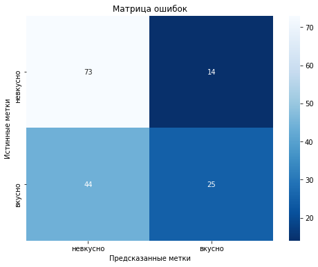

```python
cm_plot(y_test, y_pred_1)
```

Accuracy = 0.628. Модель в 62.8% случаев предсказывает верно.

Recall = 0.839. Модель довольно хорошо справляется с предсказанием значения "невкусно", в 83.9% прогнозы оказываются верными.

Precision = 0.623. Предсказать значения "вкусно" модели получается хуже, они совпадают всего в 62.3% случаев.

Самое главное — точно предсказывать вкусное молоко, поэтому вторая ошибка является более критичной для заказчика. При ошибочном прогнозе невкусного молока как вкусного фермер потерпит убытки. Поэтому необходимо провести дополнительные исследования, чтобы увеличить значение Precision.

Попробуем повысить качество модели, добавив новый признак и изменив порог принадлежности к классам.

### Вторая модель

Добавим в датасет `main_data` признак `'сахар'`, который будет отражать фактическое количество сахара в корме.

```python
main_data['сахар'] = main_data['сырой_протеин'] * main_data['спо']
```

Проверяем результат.

```python
main_data.head()
```

|  | ид | удой | эке | сырой_протеин | спо | порода | тип_пастбища | порода_папы | жирность | белок | вкус_молока | возраст | спо_категория | квадрат_эке | имя_папы | сахар |
| --- | --- | --- | --- | --- | --- | --- | --- | --- | --- | --- | --- | --- | --- | --- | --- | --- |
| 0 | 1 | 5863 | 14.2 | 1743 | 0.890 | Вис Бик Айдиал | равнинное | Айдиал | 3.58 | 3.076 | вкусно | более 2 лет | 0 | 201.64 | Буйный | 1551.270 |
| 1 | 2 | 5529 | 12.8 | 2138 | 0.890 | Вис Бик Айдиал | равнинное | Соверин | 3.54 | 3.079 | вкусно | менее 2 лет | 0 | 163.84 | Соловчик | 1902.820 |
| 2 | 3 | 5810 | 14.0 | 1854 | 0.885 | Рефлешн Соверинг | холмистое | Соверин | 3.59 | 3.074 | невкусно | более 2 лет | 0 | 196.00 | Барин | 1640.790 |
| 3 | 4 | 5895 | 12.4 | 2012 | 0.885 | Рефлешн Соверинг | холмистое | Айдиал | 3.40 | 3.075 | невкусно | более 2 лет | 0 | 153.76 | Буйный | 1780.620 |
| 4 | 5 | 5302 | 12.8 | 1675 | 0.885 | Вис Бик Айдиал | равнинное | Соверин | 3.73 | 3.073 | вкусно | менее 2 лет | 0 | 163.84 | Барин | 1482.375 |

Изучим корреляцию нового признака с другими признаками.

```python
display(HTML('<h3>Корреляция признака "сахар" с другими признаками</h3>'))
main_data[main_data.columns[1:]]\
    .phik_matrix(interval_cols=int_col(main_data))\
    .drop(main_data.columns[1:-1], axis=1)\
    .style.background_gradient('cividis')
```

Корреляция признака "сахар" с другими признаками

|  | сахар |
| --- | --- |
| удой | 0.631279 |
| эке | 0.584877 |
| сырой_протеин | 0.947162 |
| спо | 0.578580 |
| порода | 0.048366 |
| тип_пастбища | 0.059733 |
| порода_папы | 0.154166 |
| жирность | 0.585526 |
| белок | 0.223650 |
| вкус_молока | 0.200552 |
| возраст | 0.552246 |
| спо_категория | 0.818449 |
| квадрат_эке | 0.560587 |
| имя_папы | 0.194246 |
| сахар | 1.000000 |

Показатель сахара очень сильно коррелирует с сырым протеином. Оставим только один из них.

Из входных признаков исключим `'сырой_протеин'`.

```python
X_2 = main_data.drop(['вкус_молока', 'удой', 'ид', 'белок', 'жирность',
                    'порода', 'порода_папы', 'имя_папы', 'эке', 'спо', 'сырой_протеин'], axis=1)

# Создаем переменные, которые разделяют признаки на категориальные и количественные
cat_col_names_2 = cat_col(X_2)
num_col_names_2 = int_col(X_2)

# Разбиваем признаки на тренировочную и тестовую выборки
X_train_2, X_test_2 = train_test_split(X_2, random_state=RANDOM_STATE)
```

Обучаем вторую модель.

```python
# Кодируем категориальные признаки с помощью OneHotEncoder
encoder_2 = OneHotEncoder(drop='first', sparse=False)

X_train_ohe_2 = encoder_2.fit_transform(X_train_2[cat_col_names_2])
X_test_ohe_2 = encoder_2.transform(X_test_2[cat_col_names_2])

encoder_col_names_2 = encoder_2.get_feature_names()

X_train_ohe_2 = pd.DataFrame(X_train_ohe_2, columns=encoder_col_names_2)
X_test_ohe_2 = pd.DataFrame(X_test_ohe_2, columns=encoder_col_names_2)


# Масштабируем количественные признаки с помощью StandardScaler
scaler_2 = StandardScaler()

X_train_scaled_2 = scaler_2.fit_transform(X_train_2[num_col_names_2])
X_test_scaled_2 = scaler_2.transform(X_test_2[num_col_names_2])


# Объединяем все преобразованные данные в тренировочный и тестовый датафреймы
X_train_scaled_2 = pd.DataFrame(X_train_scaled_2, columns=num_col_names_2)
X_test_scaled_2 = pd.DataFrame(X_test_scaled_2, columns=num_col_names_2)

X_train_2 = pd.concat([X_train_ohe_2, X_train_scaled_2], axis=1)
X_test_2 = pd.concat([X_test_ohe_2, X_test_scaled_2], axis=1)


# Обучаем модель линейной регрессии на подготовленных данных и получаем прогноз удоя коров

clf_2 = LogisticRegression(random_state=0)

clf_2.fit(X_train_2, y_train)

y_pred_2 = clf_2.predict(X_test_2)
```

Оценим качество модели на тестовой выборке, рассчитав метрики accuracy, precision и recall.

```python
apr_metrics(y_pred_2)
```

```
Accuracy = 0.6474358974358975
Precision = 0.6428571428571429
Recall = 0.8275862068965517
```

Также рассмотрим матрицу ошибок.

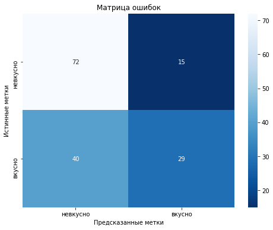

```python
cm_plot(y_test, y_pred_2)
```

Метрики accuracy и precision увеличились на 1.9%, что хорошо, но еще недостаточно. Количество верно предсказанных коров, дающих вкусное молоко возросло, но значений False Positive не уменьшилось.

Подберем порог классификации, на котором False Positive будет равен 0.

```python
# Получим вероятности принадлежности объектов к классу "вкусно"
y_proba_2 = clf_2.predict_proba(X_test_2)[:, 0]

# Преобразуем метки y_test в числа
y_test_num = [1 if label == 'вкусно' else 0 for label in y_test]
```

```python
# Создаем переменную для сохранения значения порога
threshold = 1

def optimal_threshold(threshold, step):
    # Устанавливаем начальный порог классификации
    n = threshold - step * 10

    while n < 1:
        # Применяем порог классификации
        y_pred_2 = (y_proba_2 >= n).astype('int')

        # Вычисляем значение False Positive
        fp = confusion_matrix(y_test_num, y_pred_2)[0, 1]

        # Если fp равно 0, сохраняем текущее значение порога и прерываем цикл
        if fp == 0:
            threshold = n
            break

        # Увеличиваем порог
        n += step

    # Возвращаем новое значение порога
    return threshold
```

```python
# Перебираем числа шагов от 0.1 до 0.0001, чтобы получить значение порога с точностью до десятитысячных
for step in [10**-i for i in range(1, 5)]:

    # Присваиваем возвращаемое значение порога
    threshold = optimal_threshold(threshold, step)

# Выводим оптимальное значение порога
print('Оптимальное значение порога:', round(threshold, 4))
```

```
Оптимальное значение порога: 0.7373
```

Мы получили значение оптимального значения порога, равное 0.7373. Используем его и изучим его метрики и матрицу ошибок.

```python
y_pred_2 = (y_proba_2 >= threshold).astype('int')
```

```python
print('Accuracy =', accuracy_score(y_test_num, y_pred_2))
print('Precision =', precision_score(y_test_num, y_pred_2, pos_label=1))
print('Recall =', recall_score(y_test_num, y_pred_2, pos_label=1))
```

```
Accuracy = 0.6089743589743589
Precision = 1.0
Recall = 0.2988505747126437
```

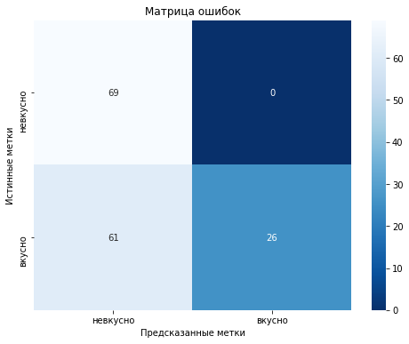

```python
cm_plot(y_test_num, y_pred_2)
```

### Прогнозирование вкуса молока

Перед составлением прогноза добавим в датасет недостающие признак `'сахар'`.

```python
buy_data['сахар'] = buy_data['сырой_протеин'] * buy_data['спо']
```

Проверяем результат.

```python
buy_data.head()
```

|  | порода | тип_пастбища | порода_папы | имя_папы | жирность | белок | возраст | эке | спо | сырой_протеин | квадрат_эке | спо_категория | удой | сахар |
| --- | --- | --- | --- | --- | --- | --- | --- | --- | --- | --- | --- | --- | --- | --- |
| 0 | Вис Бик Айдиал | холмистое | Айдиал | Геркулес | 3.58 | 3.076 | более 2 лет | 15.626615 | 0.967583 | 2045.120136 | 244.191090 | 1 | 6660.253270 | 1978.823827 |
| 1 | Вис Бик Айдиал | равнинное | Соверин | Буйный | 3.54 | 3.081 | менее 2 лет | 13.626881 | 0.918220 | 1900.239908 | 185.691879 | 0 | 5715.715173 | 1744.838637 |
| 2 | Рефлешн Соверинг | равнинное | Соверин | Барин | 3.59 | 3.074 | более 2 лет | 15.626615 | 0.967583 | 2045.120136 | 244.191090 | 1 | 6332.910287 | 1978.823827 |
| 3 | Рефлешн Соверинг | холмистое | Айдиал | Буйный | 3.40 | 3.061 | более 2 лет | 15.626615 | 0.967583 | 2045.120136 | 244.191090 | 1 | 6650.321425 | 1978.823827 |
| 4 | Рефлешн Соверинг | равнинное | Айдиал | Буйный | 3.64 | 3.074 | более 2 лет | 13.626881 | 0.918220 | 1900.239908 | 185.691879 | 0 | 5951.232924 | 1744.838637 |

Выполним подготовку данных и спрогнозируем удой коров, которых хочет купить фермер, используя модель № 2.

```python
# Подготовка данных
X_buy = buy_data.drop(['удой', 'белок', 'жирность', 'порода', 'порода_папы', 'имя_папы', 'эке', 'спо', 'сырой_протеин'], axis=1)

# Преобразование категориальных признаков
X_buy_ohe = encoder_2.transform(X_buy[cat_col_names_2])
X_buy_ohe = pd.DataFrame(X_buy_ohe, columns=encoder_col_names_2)

# Масштабирование числовых признаков
X_buy_scaled = scaler_2.transform(X_buy[num_col_names_2])
X_buy_scaled = pd.DataFrame(X_buy_scaled, columns=num_col_names_2)

# Объединение преобразованных признаков
X_buy = pd.concat([X_buy_ohe, X_buy_scaled], axis=1)

# Прогнозирование вкуса молока
y_proba_buy = clf_2.predict_proba(X_buy)[:, 0]

y_pred_buy = (y_proba_buy >= threshold).astype('int')
```

Получаем прогноз вкуса молока.

```python
y_pred_buy = np.where(y_pred_buy == 0, 'невкусно', 'вкусно')

buy_data['вкус_молока'] = y_pred_buy

buy_data.sort_values(by='вкус_молока')
```

|  | порода | тип_пастбища | порода_папы | имя_папы | жирность | белок | возраст | эке | спо | сырой_протеин | квадрат_эке | спо_категория | удой | сахар | вкус_молока |
| --- | --- | --- | --- | --- | --- | --- | --- | --- | --- | --- | --- | --- | --- | --- | --- |
| 0 | Вис Бик Айдиал | холмистое | Айдиал | Геркулес | 3.58 | 3.076 | более 2 лет | 15.626615 | 0.967583 | 2045.120136 | 244.191090 | 1 | 6660.253270 | 1978.823827 | вкусно |
| 16 | Вис Бик Айдиал | холмистое | Соверин | Соловчик | 3.73 | 3.079 | более 2 лет | 15.626615 | 0.967583 | 2045.120136 | 244.191090 | 1 | 6379.382631 | 1978.823827 | вкусно |
| 3 | Рефлешн Соверинг | холмистое | Айдиал | Буйный | 3.40 | 3.061 | более 2 лет | 15.626615 | 0.967583 | 2045.120136 | 244.191090 | 1 | 6650.321425 | 1978.823827 | вкусно |
| 15 | Рефлешн Соверинг | холмистое | Айдиал | Буйный | 3.40 | 3.065 | более 2 лет | 15.626615 | 0.967583 | 2045.120136 | 244.191090 | 1 | 6650.321425 | 1978.823827 | вкусно |
| 6 | Вис Бик Айдиал | холмистое | Айдиал | Геркулес | 3.58 | 3.076 | более 2 лет | 15.626615 | 0.967583 | 2045.120136 | 244.191090 | 1 | 6660.253270 | 1978.823827 | вкусно |
| 12 | Вис Бик Айдиал | холмистое | Айдиал | Геркулес | 3.68 | 3.046 | более 2 лет | 15.626615 | 0.967583 | 2045.120136 | 244.191090 | 1 | 6660.253270 | 1978.823827 | вкусно |
| 17 | Рефлешн Соверинг | равнинное | Соверин | Геркулес | 3.77 | 3.053 | менее 2 лет | 15.626615 | 0.967583 | 2045.120136 | 244.191090 | 1 | 6445.161206 | 1978.823827 | невкусно |
| 14 | Рефлешн Соверинг | равнинное | Соверин | Барин | 3.59 | 3.074 | более 2 лет | 15.626615 | 0.967583 | 2045.120136 | 244.191090 | 1 | 6332.910287 | 1978.823827 | невкусно |
| 13 | Вис Бик Айдиал | холмистое | Соверин | Барин | 3.42 | 3.075 | менее 2 лет | 15.626615 | 0.967583 | 2045.120136 | 244.191090 | 1 | 6149.769609 | 1978.823827 | невкусно |
| 11 | Рефлешн Соверинг | равнинное | Соверин | Геркулес | 3.73 | 3.073 | более 2 лет | 15.626615 | 0.967583 | 2045.120136 | 244.191090 | 1 | 6644.277577 | 1978.823827 | невкусно |
| 9 | Рефлешн Соверинг | холмистое | Айдиал | Буйный | 3.40 | 3.079 | менее 2 лет | 13.626881 | 0.918220 | 1900.239908 | 185.691879 | 0 | 5804.493625 | 1744.838637 | невкусно |
| 18 | Вис Бик Айдиал | равнинное | Соверин | Буйный | 3.34 | 3.069 | более 2 лет | 15.626615 | 0.967583 | 2045.120136 | 244.191090 | 1 | 6561.542972 | 1978.823827 | невкусно |
| 8 | Рефлешн Соверинг | равнинное | Соверин | Барин | 3.59 | 3.074 | более 2 лет | 15.626615 | 0.967583 | 2045.120136 | 244.191090 | 1 | 6332.910287 | 1978.823827 | невкусно |
| 7 | Вис Бик Айдиал | равнинное | Соверин | Буйный | 3.57 | 3.079 | более 2 лет | 15.626615 | 0.967583 | 2045.120136 | 244.191090 | 1 | 6561.542972 | 1978.823827 | невкусно |
| 5 | Рефлешн Соверинг | равнинное | Соверин | Геркулес | 3.63 | 3.053 | менее 2 лет | 13.626881 | 0.918220 | 1900.239908 | 185.691879 | 0 | 5798.449777 | 1744.838637 | невкусно |
| 4 | Рефлешн Соверинг | равнинное | Айдиал | Буйный | 3.64 | 3.074 | более 2 лет | 13.626881 | 0.918220 | 1900.239908 | 185.691879 | 0 | 5951.232924 | 1744.838637 | невкусно |
| 2 | Рефлешн Соверинг | равнинное | Соверин | Барин | 3.59 | 3.074 | более 2 лет | 15.626615 | 0.967583 | 2045.120136 | 244.191090 | 1 | 6332.910287 | 1978.823827 | невкусно |
| 1 | Вис Бик Айдиал | равнинное | Соверин | Буйный | 3.54 | 3.081 | менее 2 лет | 13.626881 | 0.918220 | 1900.239908 | 185.691879 | 0 | 5715.715173 | 1744.838637 | невкусно |
| 10 | Вис Бик Айдиал | холмистое | Соверин | Соловчик | 3.73 | 3.055 | более 2 лет | 13.626881 | 0.918220 | 1900.239908 | 185.691879 | 0 | 5732.671203 | 1744.838637 | невкусно |
| 19 | Рефлешн Соверинг | равнинное | Айдиал | Буйный | 3.64 | 3.074 | более 2 лет | 15.626615 | 0.967583 | 2045.120136 | 244.191090 | 1 | 6597.944352 | 1978.823827 | невкусно |

Построим график по спрогнозированным значениям.

```
Количество значений:
невкусно    14
вкусно       6
```

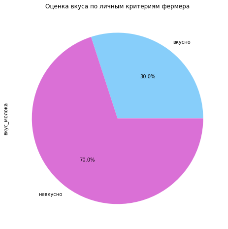

```python
print('Количество значений:')
print(buy_data['вкус_молока'].value_counts().to_string(header=False))
categorical_plot(buy_data, 'вкус_молока')
plt.title('Оценка вкуса по личным критериям фермера')
plt.show()
```

Если верить предсказанным данным, у 6 коров из стада будет получаться вкусное молоко.

У остальных коров молоко с высокой долей вероятности будет невкусным, поэтому они не подойдут.

### Вывод

Мы протестировали 2 модели логистической регрессии. Лучшей оказалась модель № 2. Из входных признаков мы исключили следующие параметры:

- `'удой'`, `'вкус_молока'` (целевые),
- `'ид'`,
- `'белок'`, `'жирность'` (характеристики молока, подобные `'вкус_молока'`),
- `'порода'`, `'порода_папы'` и `'имя_папы'` (не имеют никакой корреляции с целевым признаком),
- `'спо'`, `'эке'` (заменены ранее добавленными новыми признаками `'спо_категория'` и `'квадрат_эке'`),
- `'сырой_протеин'` (мультиколлениарный с новым введенным признаком `'сахар'`).

Для повышения качества модели мы сделали следующее:

- добавили новый признак `'сахар'` путем умножения значений `'сырой_протеин'` и `'спо'`,
- повысили порог принадлежности значений к классу "вкусно" до 73.73% за счет повышения метрики precision.

Характеристики 2 модели:

- **Accuracy** = 0.6089
- **Precision** = 1.0
- **Recall** = 0.2988
- Значение False Positive в матрице ошибок равно нулю.

Мы спрогнозировали удой коров, которых фермер хочет купить. По полученным данным можно сделать вывод, что у 6 коров из стада будет получаться вкусное молоко.

Вернуться к содержанию

## Итоговые выводы

**В процессе предобработки данных была проведена следующая работа:**

- Наименования столбцов и нечисловые данные мы оформили в соответствии со стандартами оформления данных.
- Произвели замену типов данных в столбцах.
- В датафреймах `main_data` и `buy_data` удалили явные дубликаты, а также обработали неявные дубликаты среди уникальных значений.
- Из датафрейма `main_data` было удалено 6 аномальных значений.

**После проведения анализа данных и корреляционного анализа мы сделали следующие выводы:**

- Подавляющее число коров фермера «Вольный луг» имеют возраст более 2 лет - 82.5%. Молодых коров до 2 лет меньше почти в 5 раз - всего 17.5%.
- Разброс удоя коров фермера довольно большой - от 5204 до 7222 кг в год. Ниже 5600 кг дают только коровы моложе 2 лет. 100% коров старше 2 лет с удоем менее 6000 кг в год имеют значение СПО менее 0.92 (23.4% от общей массы). Среднее значение удоя коровы старше 2 лет - 6272 кг, младше 2 лет - 5443 кг в год. Оптимальное количество молока в 6000 и более кг в год дает 59.2% коров.
- 58.9% коров фермера по его субъективной оценке имеют вкусное молоко, у 41.1% коров молоко невкусное.
- От возраста коровы зависит количество получаемого корма. У коров старше 2 лет более питательный корм - среди показателей СПО, ЭКЕ и содержания сырого протеина в корме эта категория коров гораздо чаще имеет высокие показатели. При помощи коррекции показателей корма можно влиять на удой и в некоторой степени на вкус молока.

**Результаты прогнозов моделей машинного обучения**

Отобразим итоговый список коров, подходящих под требования фермера «Вольный луг».

```python
print('Количество коров, подходящих под требования фермера:', \
      len(buy_data[(buy_data['вкус_молока'] == 'вкусно') & (buy_data['удой'] >= 6000)]))

buy_data[(buy_data['вкус_молока'] == 'вкусно') & (buy_data['удой'] >= 6000)].sort_values(by='удой')
```

```
Количество коров, подходящих под требования фермера: 6
```

|  | порода | тип_пастбища | порода_папы | имя_папы | жирность | белок | возраст | эке | спо | сырой_протеин | квадрат_эке | спо_категория | удой | сахар | вкус_молока |
| --- | --- | --- | --- | --- | --- | --- | --- | --- | --- | --- | --- | --- | --- | --- | --- |
| 16 | Вис Бик Айдиал | холмистое | Соверин | Соловчик | 3.73 | 3.079 | более 2 лет | 15.626615 | 0.967583 | 2045.120136 | 244.19109 | 1 | 6379.382631 | 1978.823827 | вкусно |
| 3 | Рефлешн Соверинг | холмистое | Айдиал | Буйный | 3.40 | 3.061 | более 2 лет | 15.626615 | 0.967583 | 2045.120136 | 244.19109 | 1 | 6650.321425 | 1978.823827 | вкусно |
| 15 | Рефлешн Соверинг | холмистое | Айдиал | Буйный | 3.40 | 3.065 | более 2 лет | 15.626615 | 0.967583 | 2045.120136 | 244.19109 | 1 | 6650.321425 | 1978.823827 | вкусно |
| 0 | Вис Бик Айдиал | холмистое | Айдиал | Геркулес | 3.58 | 3.076 | более 2 лет | 15.626615 | 0.967583 | 2045.120136 | 244.19109 | 1 | 6660.253270 | 1978.823827 | вкусно |
| 6 | Вис Бик Айдиал | холмистое | Айдиал | Геркулес | 3.58 | 3.076 | более 2 лет | 15.626615 | 0.967583 | 2045.120136 | 244.19109 | 1 | 6660.253270 | 1978.823827 | вкусно |
| 12 | Вис Бик Айдиал | холмистое | Айдиал | Геркулес | 3.68 | 3.046 | более 2 лет | 15.626615 | 0.967583 | 2045.120136 | 244.19109 | 1 | 6660.253270 | 1978.823827 | вкусно |

Из 20 представленных коров на продаже «ЭкоФермы» фермеру по его заявленным требованиям подходит 6 из них. Для снижения рисков стоит выбирать коров только из тех, кто старше 2 лет, а также стоит провести проверку здоровья коров и изучить ее историю болезней.

Для улучшения удоя и вкуса молока стоит делать упор на качестве корма и условиях содержания. Холмистые пастбища чаще дают положительное влияние на эти показатели, а также повышение показателей СПО и ЭКЕ могут дать лучшие результаты удоя и вкуса молока. Возможно, стоит привести показатели корма к общему значению для всех имеющихся коров для более стабильного и предсказуемого результата. Например, если у 23.4% уже имеющихся коров у фермера повысить показатель СПО до 0.93 и более, то с высокой долей вероятности повысятся их показатели удоя.

**Выводы о моделях линейной и логистической регрессии**

- Выбранная модель линейной регрессии для прогнозирования удоя коров показала хорошие результаты, что видно из высокого значения R². Модель хорошо объясняет изменчивость данных и может быть надежным инструментом для прогнозирования.
- Модель логистической регрессии, используемая для классификации вкуса молока, была настроена таким образом, чтобы минимизировать ложноположительные результаты. Это важно, поскольку ошибочное отнесение молока с невкусным вкусом к категории вкусного может привести к убыткам фермера.
- Для улучшения качества модели линейной регрессии мы трансформировали признак `'спо'` в категориальный, трансформировали признак `'эке'` при помощи возведения квадрат, а также добавили новый признак `'имя_папы'`.
- Для улучшения качества модели логистической регрессии мы рассчитали новый признак `'сахар'`, а также повысили порог определения значений к классу "вкусно" до 73.73% для уменьшения ошибочного прогноза невкусного молока как вкусного.
- На данном этапе нет возможности улучшить результаты регрессионой модели. Для увеличения точности моделей не хватает новых признаков, которые могли бы повлиять на качество моделей.
- При анализе рисков или экономических расчётов у моделей классификации, в том числе логистической регрессии, используют такие метрики:
  - ROC-кривая позволяет оценить способность модели различать классы. Она показывает зависимость между чувствительностью (вероятность правильного определения положительного класса) и специфичностью (вероятность правильного определения отрицательного класса) при различных порогах отсечения. Чем ближе кривая к верхнему левому углу, тем лучше.
  - AUC-ROC - это площадь под ROC-кривой. Чем выше эта метрика, тем лучше модель различает классы.
  - Коэффициент детерминации R² показывает, как хорошо модель объясняет вариацию в данных.
  - Accuracy показывает, как часто модель правильно классифицирует объекты. Accuracy вычисляется как отношение числа правильно классифицированных объектов ко всем объектам в выборке. Однако, accuracy может быть обманчивой, особенно если у вас есть дисбаланс классов.
  - Precision и Recall - эти метрики оценивают точность и полноту прогнозов. Они особенно важны, если в данных есть дисбаланс классов.
  - F1-мера - это гармоническое среднее между Precision и Recall. Она учитывает оба аспекта: как точно модель предсказывает положительные классы и как много из них она обнаруживает. F1-мера хорошо работает в случае дисбаланса классов.

Вернуться к содержанию